# HW5

Claire

2018年10月31日

# 9.42

## a.

##### Condition 1: 俱樂部裡長期下來固定有5%的會員使用服務，是fixed population

##### Condition 2: 題目說是“長期”下來統計有5%的會員使用服務，就是所謂的numerous times

##### Condition 3: n=400,p=0.05，np=20,n(1-p)=380，皆>10，是夠大的

```r
400*0.05
```

```
## [1] 20
```

```r
400*0.95
```

```
## [1] 380
```

## b.

##### n=400,p=0.05

## c.

##### mean=p=0.05,

##### Standard deviation =(p(1-p)/n)^(1/2)=0.01089725

```r
sqrt((0.05*(1-0.05))/400)
```

```
## [1] 0.01089725
```

## d.

##### 0.07

##### 0.03322871

```r
28/400
```

```
## [1] 0.07
```

```r
mean<-0.05
n<-400
sd<-(mean*(1-mean)/n)^(1/2)
1-pnorm(0.07,mean,sd)
```

```
## [1] 0.03322871
```

# 9.54

# a

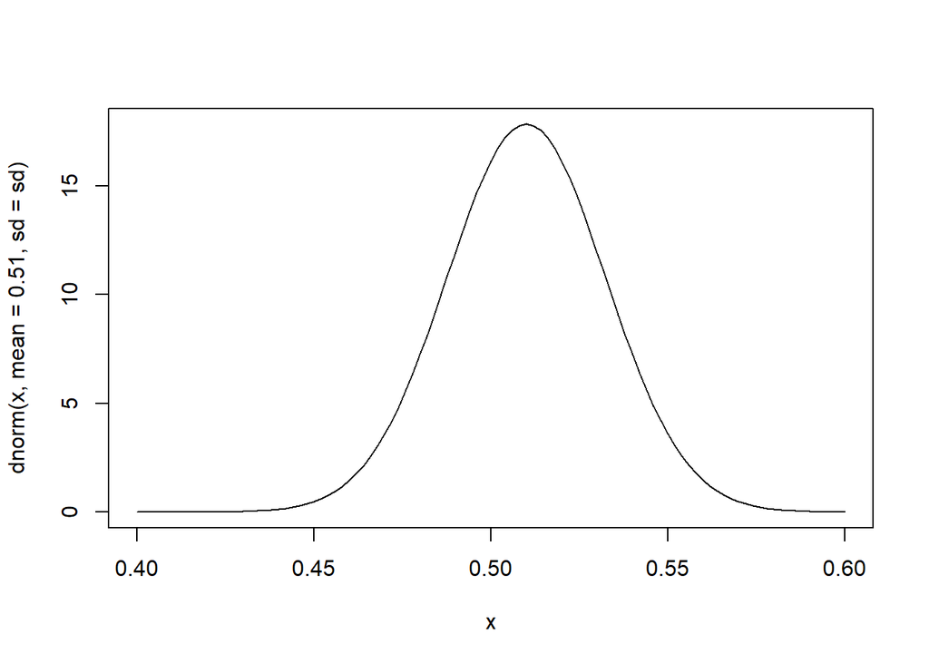

```r
n=500
p=0.51
sd=sqrt(p*(1-p)/n)
curve(dnorm(x,mean=0.51,sd=sd),xlim=c(0.4,0.6))
```

# b

```r
0.51-0.48
```

```
## [1] 0.03
```

# c

```r
var1<-0.51*(1-0.51)/500
var2<-0.48*(1-0.48)/500
sdall<-sqrt(var1+var2)
sdall
```

```
## [1] 0.03160696
```

# d

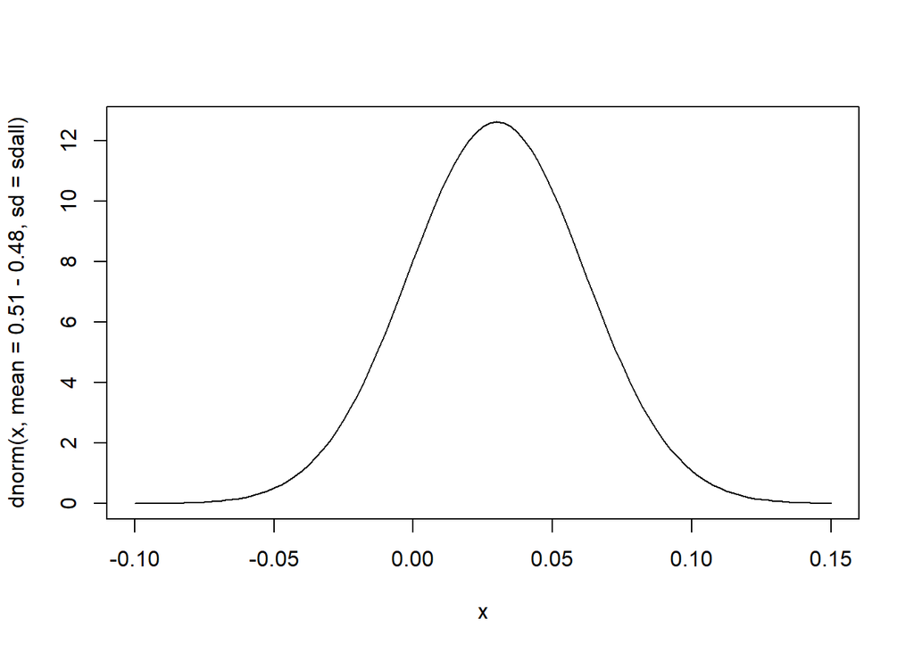

```r
curve(dnorm(x,mean=0.51-0.48,sd=sdall),xlim=c(-0.1,0.15))
```

# e

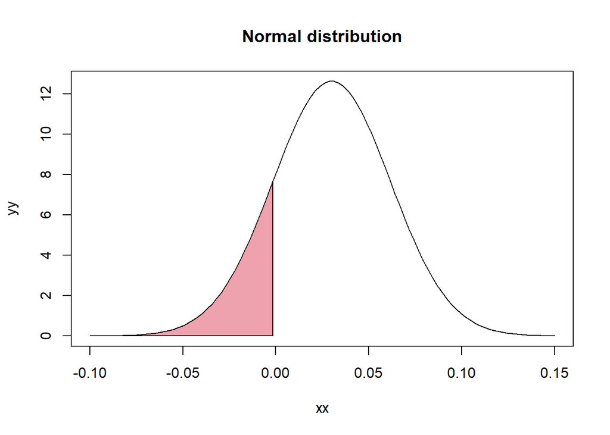

```r
xx = seq(-0.1, 0.15, length.out = 100)
yy = dnorm(xx, mean = 0.03, sd = sdall)

plot(x = xx, y = yy, type = "l", main = "Normal distribution")
axis(side = 1, at = seq(1,10,by=1))

region.x = xx[xx>=-0.1 & xx<=0]
region.y = yy[xx>=-0.1 & xx<=0]


region.x2 = c(head(region.x,1), region.x, tail(region.x,1))
region.y2 = c(0, region.y, 0)
#head()
#tail()

polygon(region.x2, region.y2, col = "lightpink2")
```

# f

```r
z<-(0-0.03)/sdall
z
```

```
## [1] -0.949158
```

#### -0.949158約等於-0.95，根據查表，約有0.1711的機率早上的投票率比下午的投票率低

# 9.68

## a

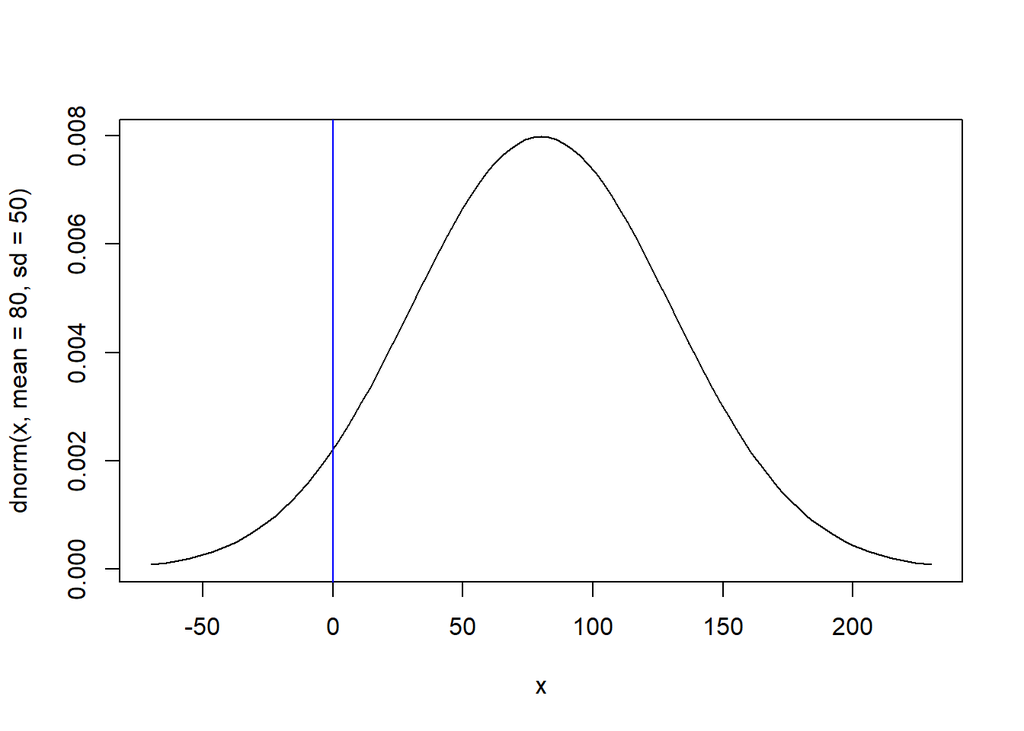

```r
curve(dnorm(x,mean=80,sd=50),from=-70,to=230)
abline(v = 0, col = "blue")
```

#### skewed to right 是因為小於0的值根據題意是不可能的(藍線往左是不可能的值)，如果有outlier也是在右邊的異常高值，不會是小於0的異常低值

## b.

#### 雖然population不是bell-shaped，但是有超過30(365>30)的random sample 的條件，因此mean值的distribution 依然是normal distribution

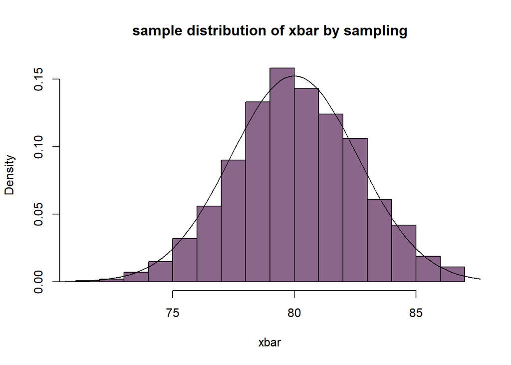

```r
sd<-50/sqrt(365)
car<-function(mu,sigma,n){
  samp=rnorm(n,mean=mu,sd=sigma)
  xbar=mean(samp)
  return(xbar)

}
simu.xbar=c()
for(j in 1:1000){
  x=car(mu=80,sigma=50,n=365)
  simu.xbar[j]=x
}
hist(simu.xbar,probability = T,breaks=20,main="sample distribution of xbar by sampling",xlab="xbar",col = "plum4")

curve(dnorm(x,mean=80,sd),from=70,to=90,add=T)
```

## c.

#### 一年中每天的總里程數相當於每個值*365，因此mean*365，sd*365的結果仍然會是常態分佈

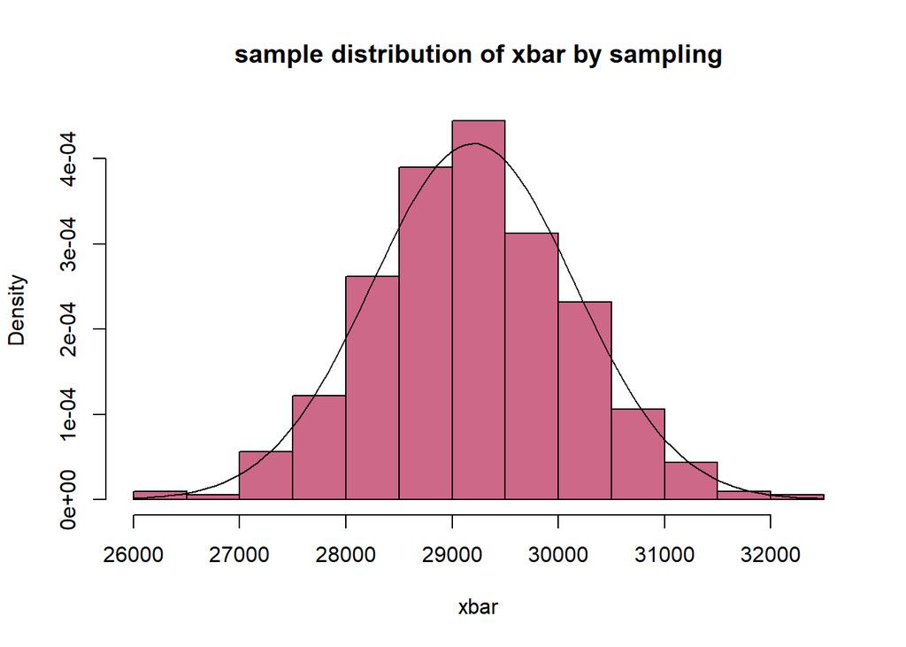

```r
sd<-50/sqrt(365)
car<-function(mu,sigma,n){
  samp=rnorm(n,mean=mu,sd=sigma)
  xbar=mean(samp)
  return(xbar)

}
simu.xbar=c()
for(j in 1:1000){
  x=car(mu=80*365,sigma=50*365,n=365)
  simu.xbar[j]=x
}
hist(simu.xbar,probability = T,breaks=20,main="sample distribution of xbar by sampling",xlab="xbar",col = "palevioletred3")

curve(dnorm(x,mean=80*365,sd*365),add=T)
```

# d.

##### Yes,雖然population不是bell-shaped，但是有超過30(365>30)的random sample 的條件，因此mean值的distribution 依然是normal distribution

# 9.74

## b.

##### d_bar，50個學生每一個人brand1與brand2沒爆開的爆米花的相差數量。

## c.

#### Yes,a題會變成μ1-μ2，b題會變成x1_bar-x2_bar

## d.

##### mean=10, sd=0.7071068

```r
mean<-10
sd<-5/sqrt(50)
sd
```

```
## [1] 0.7071068
```

## e.

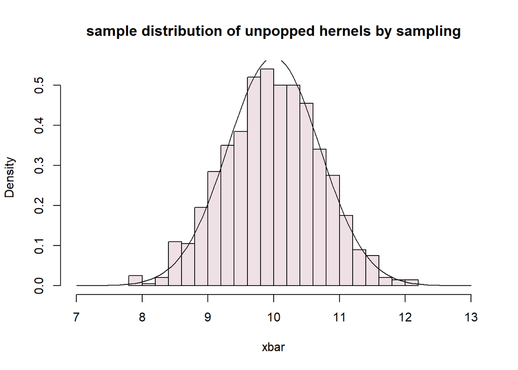

```r
popcorn<-function(mu,sigma,n){
  samp=rnorm(n,mean=mu,sd=sigma)
  xbar=mean(samp)
  return(xbar)

}
simu.xbar=c()
for(j in 1:1000){
  x=popcorn(mu=10,sigma=5,n=50)
  simu.xbar[j]=x
}
hist(simu.xbar,probability = T,breaks=20,main="sample distribution of unpopped hernels by sampling",xlab="xbar",col = "lavenderblush2",xlim=c(7,13))
curve(dnorm(x,10,0.7),xlim=c(7,13),add=T)
```

## f

##### 這種情況的確出乎意料之外，以上題模型來說，store brand 在常態中會比 name brand少約7~13粒未爆的爆米花，

#### 如果有比name brand多50粒的狀況，會位於上圖負數的地方，很明顯屬於outlier。

# 9.80

## a.

##### 因為題目設定服用兩種藥物症狀持續的時間差是沒有差異的，因此mean=0

## b.

##### 0.5137247

```r
sd<-sqrt((1.5^2/25)+(2^2/23))
sd
```

```
## [1] 0.5137247
```

## c

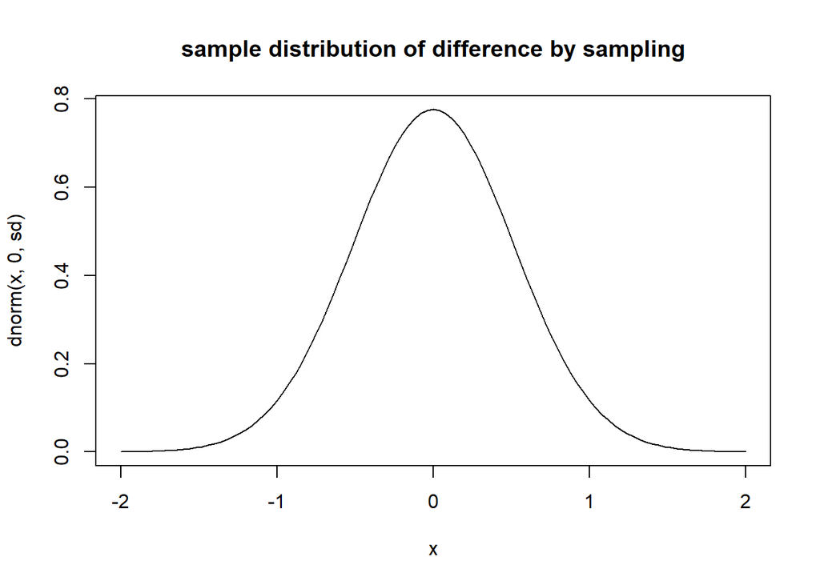

```r
curve(dnorm(x,0,sd),xlim=c(-2,2),main="sample distribution of difference by sampling")
```

## d.

##### No,因為3.6的差異值落在上圖常態分佈以外的地方，是個outlier，所以並不合理。

## e.

##### No,因為根據d的結果，服用兩種不同藥物所度過的症狀期是有明顯差異的(3.6位於三個標準差外)

# 9.106

## a

##### -1.2

```r
(97-100)/(15/sqrt(36))
```

```
## [1] -1.2
```

## b.

##### 2

```r
(105-100)/(15/sqrt(36))
```

```
## [1] 2
```

## c.

##### mean=100

##### sd=2.5

```r
mu<-100
sigma<-15
n<-36
theo.mean=mu
theo.sd=sigma/sqrt(n)
theo.mean
```

```
## [1] 100
```

```r
theo.sd
```

```
## [1] 2.5
```

## d.

##### 橘色線是97，紅色線是105

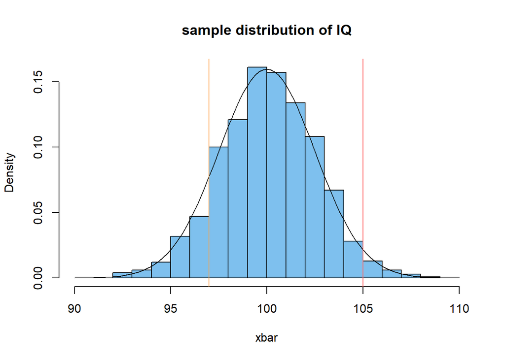

```r
IQ<-function(mu,sigma,n){
  samp=rnorm(n,mean=mu,sd=sigma)
  xbar=mean(samp)
  return(xbar)

}
simu.xbar=c()
for(j in 1:1000){
  x=IQ(mu=100,sigma=15,n=36)
  simu.xbar[j]=x
}
hist(simu.xbar,probability = T,breaks=20,main="sample distribution of IQ",xlab="xbar",col = "skyblue2",xlim=c(90,110))
curve(dnorm(x,100,2.5),xlim=c(90,110),add=T)
abline(v = 97, col = "tan1")
abline(v = 105, col = "indianred1")
```

## e.

##### 橘色線是97，紅色線是105

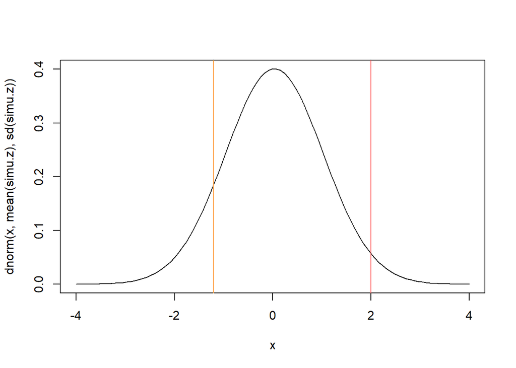

```r
simu.z<-(simu.xbar-theo.mean)/(theo.sd)
curve(dnorm(x,mean(simu.z),sd(simu.z)),xlim=c(-4,4))
z97<-(97-theo.mean)/(theo.sd)
z105<-(105-theo.mean)/(theo.sd)
abline(v = z97, col = "tan1")
abline(v = z105, col = "indianred1")
```

## f.

##### e的數值是經過z-score（標準化）的程序轉換而來的，因此標準化後的mean=0,sd=1,資料分布的形狀與parts(a),(b)的相對位置是一樣的

# Example 9.4

```r
candidate<-function(n,p){
  samp=sample(x=c(0,1),n,replace = T,prob=c(1-p,(p)))
  phat=sum(samp)/n
  return(phat)

}
simu.phat=c()
for(j in 1:1000){
  x=candidate(2400,0.4)
  simu.phat[j]=x
}
```

```r
mean9.4<-mean(simu.phat)
mean9.4
```

```
## [1] 0.4001842
```

```r
sd9.4<-sqrt((mean9.4*(1-mean9.4))/2400)
sd9.4
```

```
## [1] 0.01000077
```

```r
theo.mean<-0.4
theo.mean
```

```
## [1] 0.4
```

```r
theo.sd<-sqrt((0.4*(1-0.4))/2400)
theo.sd
```

```
## [1] 0.01
```

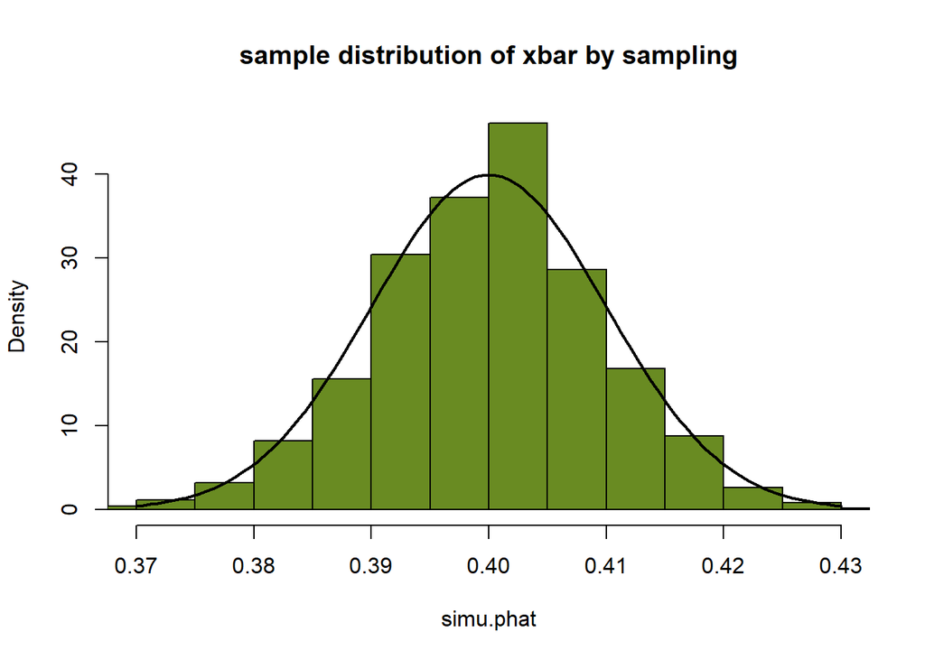

```r
hist(simu.phat,probability = T,breaks=20,main="sample distribution of xbar by sampling",col = "olivedrab4",xlim=c(0.37,0.43))
curve(dnorm(x, mean = theo.mean, sd = theo.sd), add = T,lwd=2)
```

##### 樣本分布與理論值大致相同

### Z-Score distribution

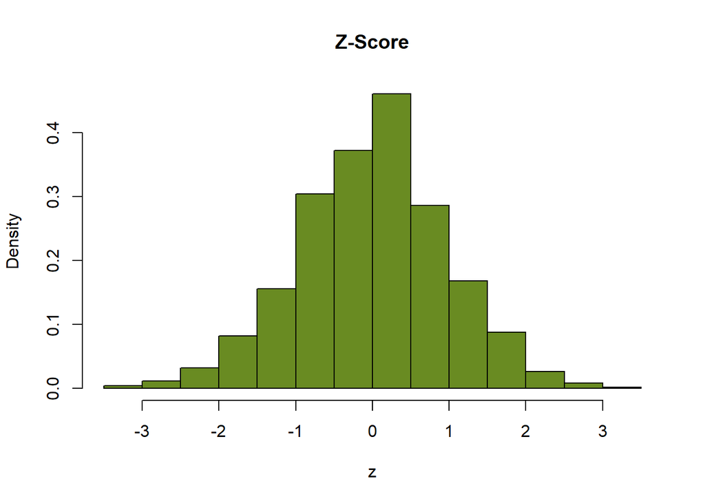

```r
z<-(simu.phat-theo.mean)/theo.sd
hist(z,probability = T,breaks=20,main="Z-Score",col = "olivedrab4")
```

# Example 9.6

```r
p1<-0.379
n1<-1017
p2<-0.287
n2<-885

DP<-function(n,p){
  samp=sample(x=c(0,1),n,replace = T,prob=c(1-p,(p)))
  phat=sum(samp)/n
  return(phat)

}
simu.p1=c()
for(j in 1:1000){
  x=DP(n1,p1)
  simu.p1[j]=x
}

simu.p2=c()
for(j in 1:1000){
  x=DP(n2,p2)
  simu.p2[j]=x
}

simu.dif<-simu.p1-simu.p2
```

```r
mean9.6<-mean(simu.dif)
mean9.6
```

```
## [1] 0.09260084
```

```r
sd9.6<-sd(simu.dif)
sd9.6
```

```
## [1] 0.02139859
```

```r
theo.mean=p1-p2
theo.mean
```

```
## [1] 0.092
```

```r
theo.sd=sqrt((p1*(1-p1)/n1)+(p2*(1-p2)/n2))
theo.sd
```

```
## [1] 0.02150921
```

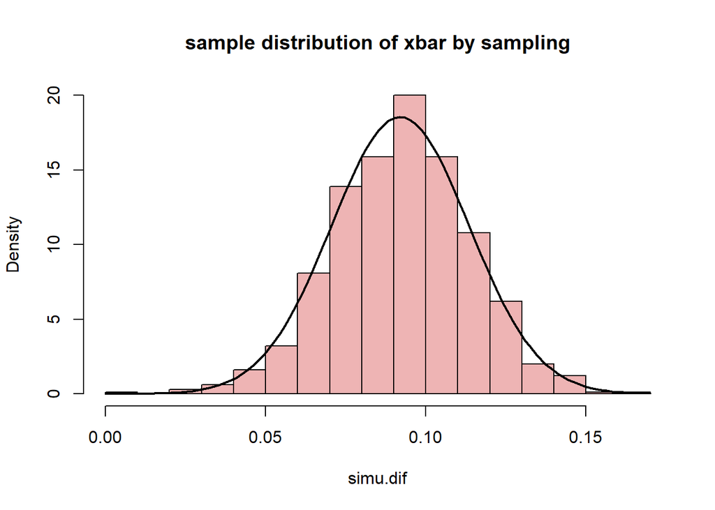

```r
hist(simu.dif,probability = T,breaks=20,main="sample distribution of xbar by sampling",col = "rosybrown2")
curve(dnorm(x, mean = theo.mean, sd = theo.sd), add = T,lwd=2)
```

##### 樣本分布與理論值大致相同

### Z-Score distribution

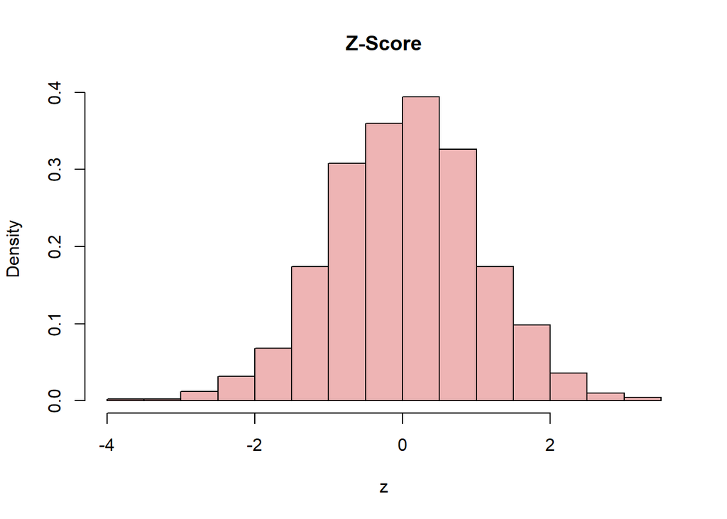

```r
z<-(simu.dif-theo.mean)/theo.sd
hist(z,probability = T,breaks=20,main="Z-Score",col = "rosybrown2")
```

## Exsample9.8

```r
weight_loss<-function(mu,sigma,n){
  samp=rnorm(n,mean=mu,sd=sigma)
  xbar=mean(samp)
  return(xbar)

}
simu.xbar=c()
for(j in 1:1000){
  x=popcorn(mu=8,sigma=5,n=25)
  simu.xbar[j]=x
}
```

```r
mean9.8<-mean(simu.xbar)
mean9.8
```

```
## [1] 7.988479
```

```r
sd9.8<-sd(simu.xbar)
sd9.8
```

```
## [1] 1.011884
```

```r
theo.mean<-8
theo.mean
```

```
## [1] 8
```

```r
theo.sd<-5/sqrt(25)
theo.sd
```

```
## [1] 1
```

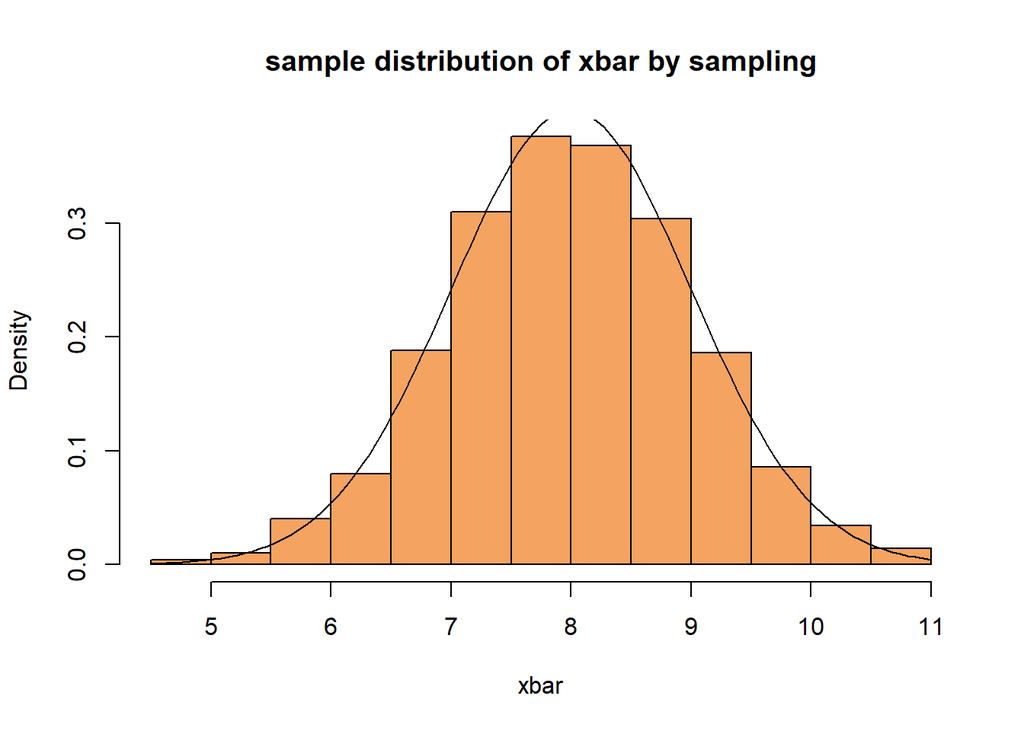

```r
hist(simu.xbar,probability = T,breaks=20,main="sample distribution of xbar by sampling",xlab="xbar",col = "sandybrown")
curve(dnorm(x,theo.mean,theo.sd),add=T)
```

##### 樣本分布與理論值大致相同

### Z-Score distribution

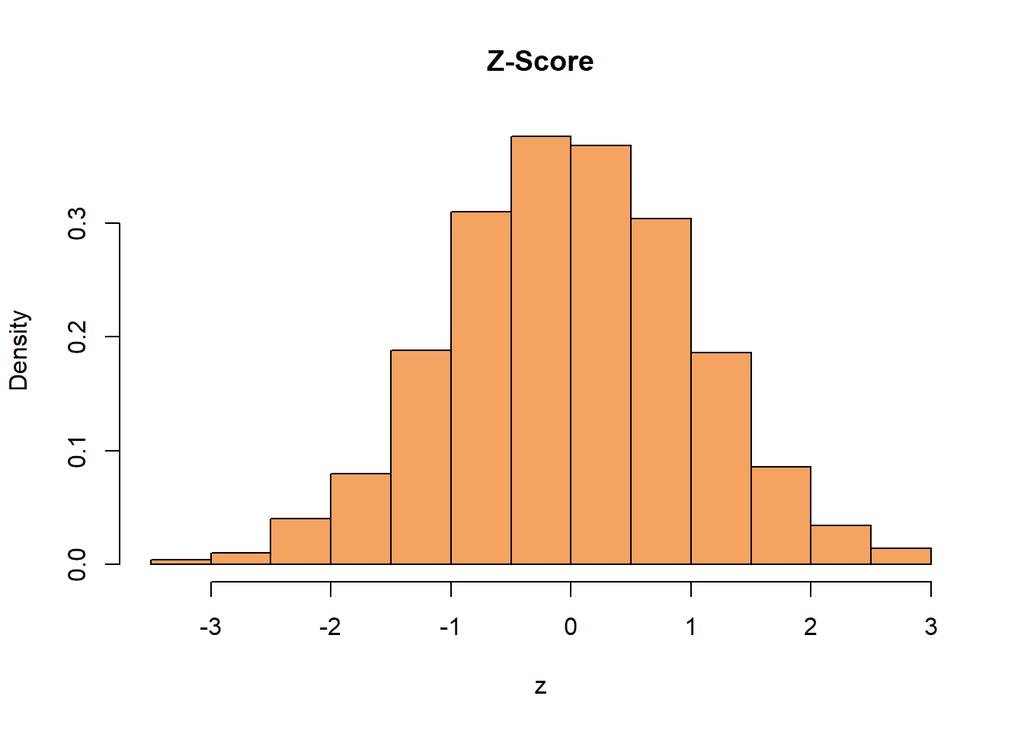

```r
z<-(simu.xbar-theo.mean)/theo.sd
hist(z,probability = T,breaks=20,main="Z-Score",col = "sandybrown")
```

## Exsample9.9

```r
weight_gain<-function(mu,sigma,n){
  samp=rnorm(n,mean=mu,sd=sigma)
  xbar=mean(samp)
  return(xbar)

}
simu.xbar=c()
for(j in 1:1000){
  x=popcorn(mu=0,sigma=7,n=60)
  simu.xbar[j]=x
}
```

```r
mean9.9<-mean(simu.xbar)
mean9.9
```

```
## [1] -0.002757988
```

```r
sd9.9<-sd(simu.xbar)
sd9.9
```

```
## [1] 0.9188713
```

```r
theo.mean<-0
theo.mean
```

```
## [1] 0
```

```r
theo.sd<-7/sqrt(60)
theo.sd
```

```
## [1] 0.9036961
```

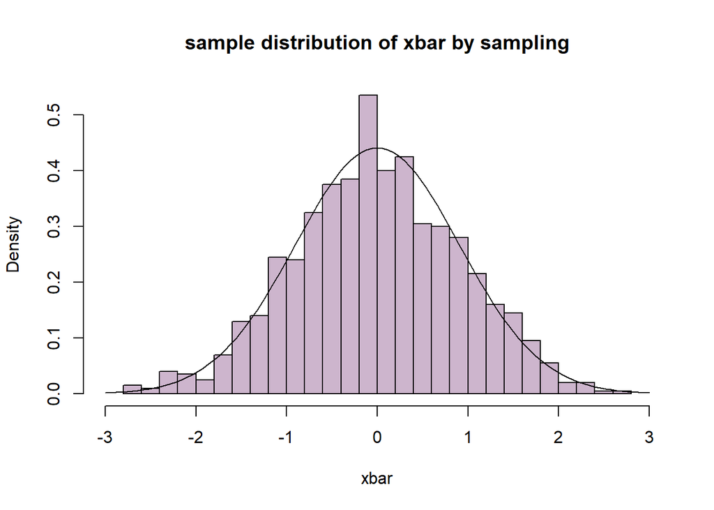

```r
hist(simu.xbar,probability = T,breaks=20,main="sample distribution of xbar by sampling",xlab="xbar",col = "thistle3",xlim=c(-3,3))
curve(dnorm(x,theo.mean,theo.sd),add=T)
```

##### 樣本分布與理論值大致相同

### Z-Score distribution

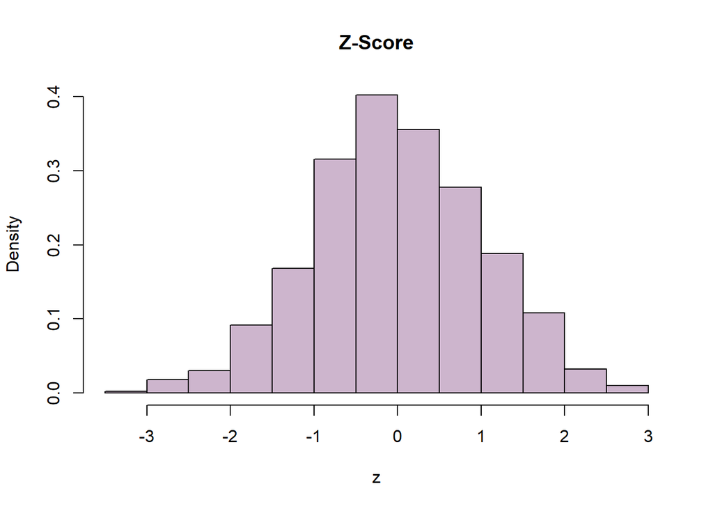

```r
z<-(simu.xbar-theo.mean)/theo.sd
hist(z,probability = T,breaks=20,main="Z-Score",col = "thistle3")
```

## Example 9.10

```r
car_speed<-function(mu,sigma,n){
  samp=rnorm(n,mean=mu,sd=sigma)
  xbar=mean(samp)
  return(xbar)

}
simu.xbar1=c()
for(j in 1:1000){
  x=popcorn(mu=0,sigma=15,n=87)
  simu.xbar1[j]=x
}

simu.xbar2=c()
for(j in 1:1000){
  x=popcorn(mu=0,sigma=15,n=102)
  simu.xbar2[j]=x
}

simu.xbar<-simu.xbar1-simu.xbar2
```

```r
mean9.10<-mean(simu.xbar)
mean9.10
```

```
## [1] 0.0820801
```

```r
sd9.10<-sd(simu.xbar)
sd9.10
```

```
## [1] 2.161718
```

```r
theo.mean<-0
theo.mean
```

```
## [1] 0
```

```r
theo.sd<-sqrt(15^2/87+15^2/102)
theo.sd
```

```
## [1] 2.189084
```

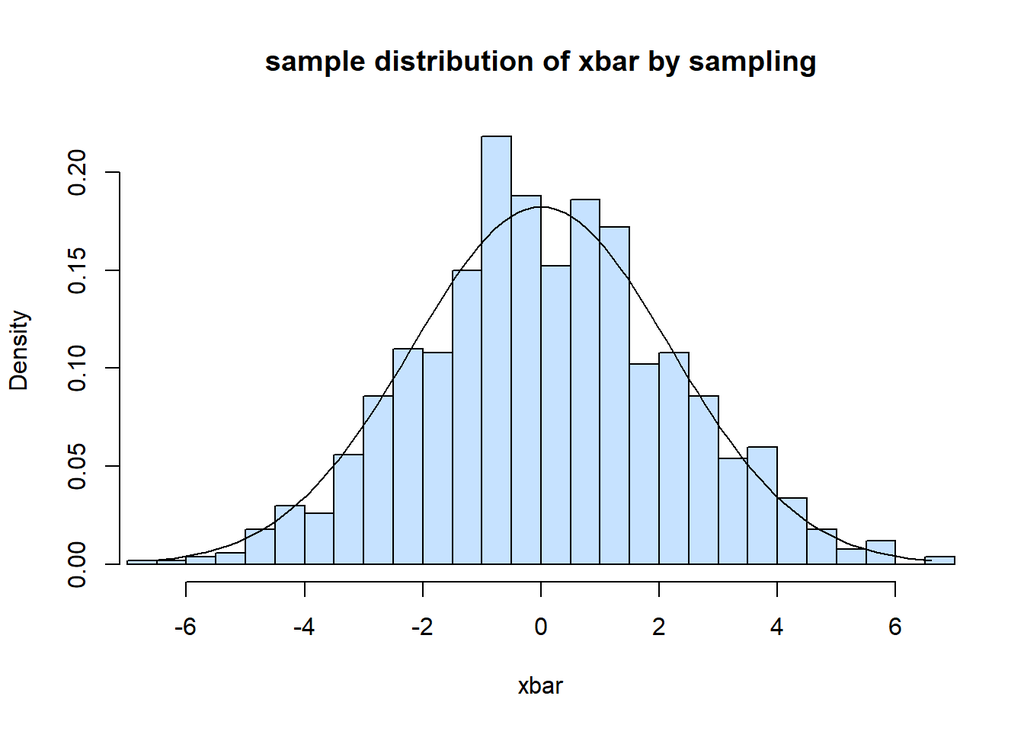

```r
hist(simu.xbar,probability = T,breaks=20,main="sample distribution of xbar by sampling",xlab="xbar",col = "slategray1",xlim=c(-6.6,6.6))
curve(dnorm(x,theo.mean,theo.sd),add=T)
```

##### 樣本分布與理論值大致相同

### Z-Score distribution

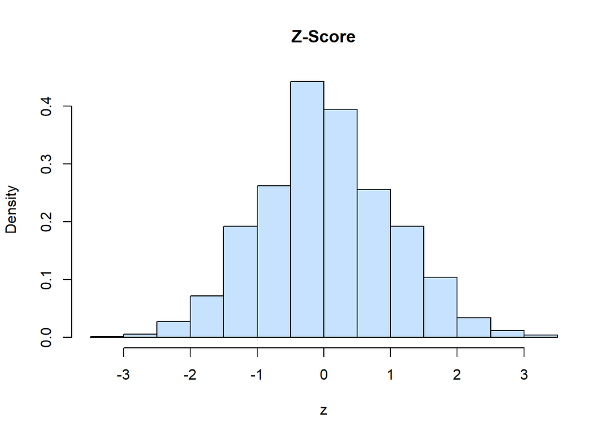

```r
z<-(simu.xbar-theo.mean)/theo.sd
hist(z,probability = T,breaks=20,main="Z-Score",col = "slategray1")
```